### AdaptWest Climate Metrics Tour

### How are high-resolution climate projections created?

Global projections of future climate are typically available at very coarse resolutions and must be “downscaled” to be relevant to regional planning. The climate data and metrics shown in this viewer are generated by a method known as statistical downscaling, using the [ClimateNA](http://cfcg.forestry.ubc.ca/projects/climate-data/climatebcwna/) software developed by Tongli Wang. The ClimateNA software dynamically develops local regression models of the relationship between elevation and current climate (as modeled by [PRISM](http://www.prism.oregonstate.edu/) data; panel C below). This dynamic local regression allows climate data to interpolated to the spatial resolution needed by a particular user. Then, ClimateNA uses the anomaly approach to develop downscaled future climate projections. First, the difference or anomaly between modeled coarse-resolution current and future climate projections is measured (A). Then this anomaly is interpolated to the desired spatial resolution (B) and added to the fine-resolution current climate layer previously developed from PRISM data to produce the downscaled projections (D).

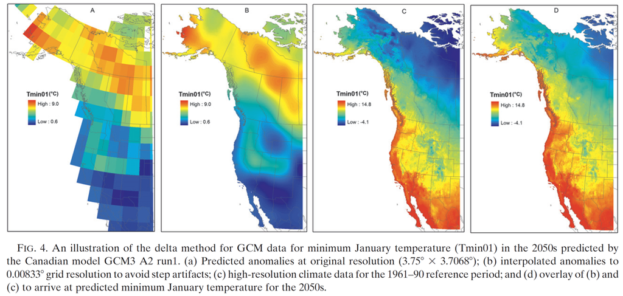

*Figure from [Wang et al 2012](https://journals.ametsoc.org/doi/10.1175/JAMC-D-11-043.1).*

Temperature shifts are only one dimension of climate change. ClimateNA calculates additional “bioclimatic” variables, which are more closely linked to ecological factors, from the temperature and precipitation projections. Most climate exposure metrics shown in this viewer are measured in terms of multivariate climate characteristics, via a principal components analysis (PCA) of 11 biologically-relevant temperature and precipitation variables. PCA provides a multivariate representation of climate change while retaining the low dimensionality that facilitates development of computationally-complex metrics such as climatic velocity. The different components of the PCA results measure different aspects of climate. Annual temperature dominates the first PCA axis (PCA1; panel a below). Annual precipitation dominates PCA2 (b). Seasonality of temperature and precipitation dominate PCA3 & PCA4, respectively.

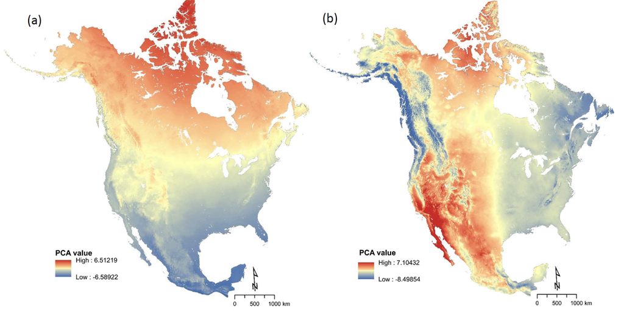

*PCA axes 1 (a) and 2 (b).*

Future climate projections are uncertain, in part due to variation between different climate models (GCM), and in part due to uncertainty concerning the pace at which society will reduce emissions. The information in this viewer focuses primarily on RCP8.5, which represents the current “business-as-usual” emissions trajectory. RCP4.5, in contrast, represents a future in which society reduces emissions more rapidly.

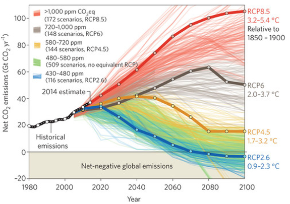

*Figure from [Fuss et al. 2014](https://www.nature.com/articles/nclimate2392) illustrates the range of projected future climate trajectories.*